# Análise venda de imóveis

Jairo Lopes

# Resumo

Este projeto fará uma análise exploratória dos dados de um dataset de venda de casas, para realizar a predição de preços de novas casas com caracteristicas semelhantes as ja vendidas

# Visão geral do dataset¶

Verificando quantidade de registros e de colunas respectivamente do conjunto de dados

```r
df %>% str %>% knitr::kable()
```

```
## spec_tbl_df[,7] [5,000 × 7] (S3: spec_tbl_df/tbl_df/tbl/data.frame)
##  $ media de lucro de venda: num [1:5000] 79545 79249 61287 63345 59982 ...
##  $ media idade das casas  : num [1:5000] 5.68 6 5.87 7.19 5.04 ...
##  $ media numero de salas  : num [1:5000] 7.01 6.73 8.51 5.59 7.84 ...
##  $ media numero de quartos: num [1:5000] 4.09 3.09 5.13 3.26 4.23 4.04 3.41 2.42 2.3 6.1 ...
##  $ populacao da regiao    : num [1:5000] 23087 40173 36882 34310 26354 ...
##  $ valor da casa          : num [1:5000] 1059034 1505891 1058988 1260617 630943 ...
##  $ endereco               : chr [1:5000] "208 Michael Ferry Apt. 674\nLaurabury, NE 37010-5101" "188 Johnson Views Suite 079\nLake Kathleen, CA 48958" "9127 Elizabeth Stravenue\nDanieltown, WI 06482-3489" "USS Barnett\nFPO AP 44820" ...
##  - attr(*, "spec")=
##   .. cols(
##   ..   `Avg. Area Income` = col_double(),
##   ..   `Avg. Area House Age` = col_double(),
##   ..   `Avg. Area Number of Rooms` = col_double(),
##   ..   `Avg. Area Number of Bedrooms` = col_double(),
##   ..   `Area Population` = col_double(),
##   ..   Price = col_double(),
##   ..   Address = col_character()
##   .. )
```

[output not shown]

```r
df %>% head(4) %>% knitr::kable()
```

| media de lucro de venda | media idade das casas | media numero de salas | media numero de quartos | populacao da regiao | valor da casa | endereco |
| --- | --- | --- | --- | --- | --- | --- |
| 79545.46 | 5.682861 | 7.009188 | 4.09 | 23086.80 | 1059034 | 208 Michael Ferry Apt. 674 |
| Laurabury, NE 37010-5101 |  |  |  |  |  |  |
| 79248.64 | 6.002900 | 6.730821 | 3.09 | 40173.07 | 1505891 | 188 Johnson Views Suite 079 |
| Lake Kathleen, CA 48958 |  |  |  |  |  |  |
| 61287.07 | 5.865890 | 8.512727 | 5.13 | 36882.16 | 1058988 | 9127 Elizabeth Stravenue |
| Danieltown, WI 06482-3489 |  |  |  |  |  |  |
| 63345.24 | 7.188236 | 5.586729 | 3.26 | 34310.24 | 1260617 | USS Barnett |
| FPO AP 44820 |  |  |  |  |  |  |

# Visualizando a distribuição de preços das casas por quantidade de quartos

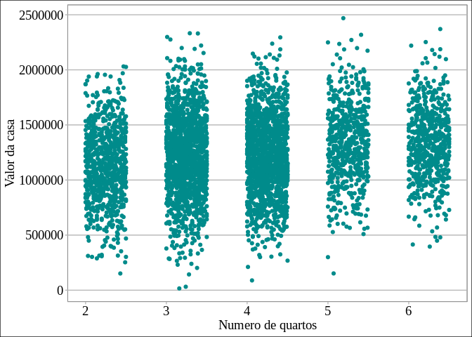

```r
ggplot(df, aes(x=df$`media numero de quartos`, y=df$`valor da casa`)) + geom_point(color="cyan4") + theme_calc() +

labs(x="Numero de quartos",y="Valor da casa", parse = F, colour = "black", size = 12,family="Times New Roman") +
theme(text=element_text(size=14, family="Times New Roman", colour="black"), axis.text=element_text(family="Times New Roman", size=14,colour="black"))
```

**OBS:** Não há grande variação de preço por numero de quartos, mas da pra perceber que casas que contém em media 2 quartos, são um pouco mais baratas em seu **valor máximo**

# Visualizando a distribuição de preços das casas por quantidade de salas

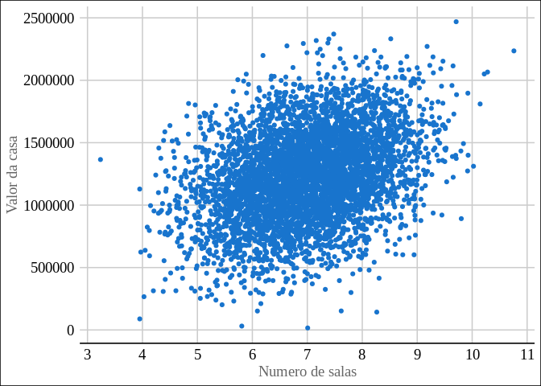

```r
ggplot(df, aes(x = df$`media numero de salas`, y=df$`valor da casa`)) + geom_point(color="dodgerblue3") + theme_gdocs() +
scale_x_continuous(breaks = seq(3, 11, by=1)) +

labs(x="Numero de salas",y="Valor da casa", parse = F, colour = "black", size = 12,family="Times New Roman") +
theme(text=element_text(size=14, family="Times New Roman", colour="black"), axis.text=element_text(family="Times New Roman", size=14,colour="black"))
```

**OBS:** obviamente, quanto maior a quantidade de salas, maior o preço da casa, em alguns poucos casos, casas com numero menor de salas sao mais caras

**OBS 2:** Também é possivel notar que a grande maioria das casas possuem entre 6 a 8 salas

# Visualizando a distribuição de salas por quantidade de quartos

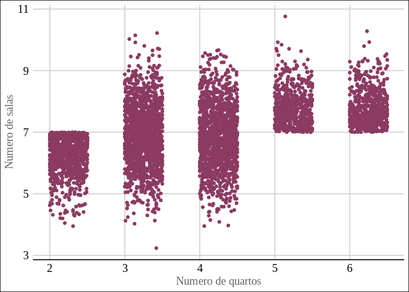

```r
ggplot(df, aes(x=df$`media numero de quartos`, y=df$`media numero de salas`)) + geom_point(color="hotpink4") + theme_gdocs() +

labs(x="Numero de quartos",y="Numero de salas", parse = F, colour = "black", size = 12,family="Times New Roman") +
theme(text=element_text(size=14, family="Times New Roman", colour="black"), axis.text=element_text(family="Times New Roman", size=14,colour="black"))
```

**OBS:** Podemos ver que todas as casas com 5 quartos ou mais, possuem no mínimo 7 salas

**OBS 2:** Também observamos que casas com 2 quartos, possuem no maximo 7 salas

# Visualizando distribuição do preço da casa baseado pela idade da mesma

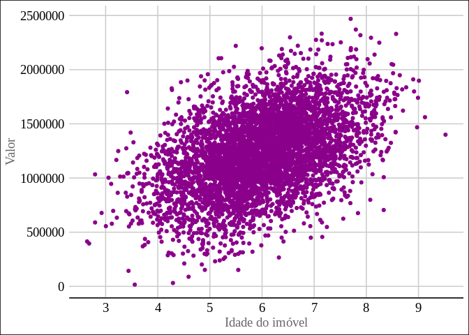

```r
ggplot(df, aes(x=df$`media idade das casas`, y=df$`valor da casa`)) + geom_point(color="magenta4") + theme_gdocs() +
scale_x_continuous(breaks = seq(0,10,1)) +
labs(x="Idade do imóvel",y="Valor", parse = F, colour = "black", size = 12,family="Times New Roman") +
theme(text=element_text(size=14, family="Times New Roman", colour="black"), axis.text=element_text(family="Times New Roman", size=14,colour="black"))
```

**OBS:** E mais uma amostra linear onde indica que, quanto mais velha a casa, maior o seu valor

# Visualizando distribuição de preços da casa por tamanho da população da região

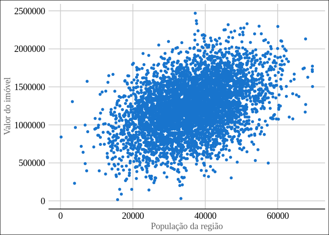

```r
ggplot(df, aes(y=df$`valor da casa`, x=df$`populacao da regiao`)) + geom_point(color="dodgerblue3") + theme_gdocs() +
labs(x="População da região",y="Valor do imóvel", parse = F, colour = "black", size = 12,family="Times New Roman") +
theme(text=element_text(size=14, family="Times New Roman", colour="black"), axis.text=element_text(family="Times New Roman", size=14,colour="black"))
```

**OBS:** Quanto maior a população da região, maior o valor do imóvel

# Visualizando correlações entre as variáveis

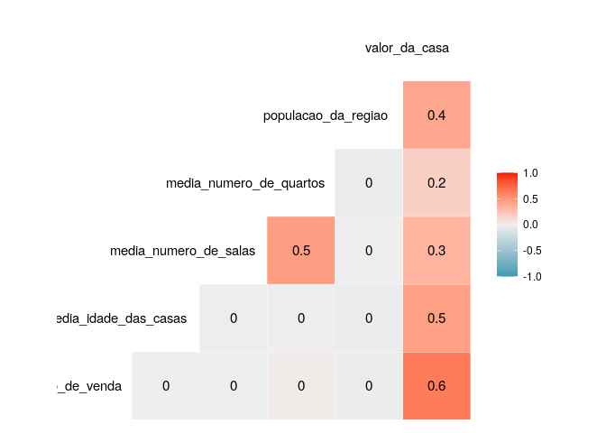

```r
ggcorr(df, label = T, hjust = 0.85)
```

**OBS:** O numero de quartos nao tem uma correlação forte com o valor da casa

# Filtrando variáveis significantes para o modelo

```r
Y <-  df$`valor da casa`
x1 <- df$`media de lucro de venda`
x2 <- df$`media idade das casas`
x3 <- df$`media numero de salas`
x4 <- df$`populacao da regiao`


model <- lm(Y ~ x1+ x2 + x3 + x4)
model
```

```
##
## Call:
## lm(formula = Y ~ x1 + x2 + x3 + x4)
##
## Coefficients:
## (Intercept)           x1           x2           x3           x4
## -2637560.67        21.58    165657.87    121598.16        15.20
```